# Project Foundations for Data Science: FoodHub Data Analysis

**Marks: 40**

### Context

The number of restaurants in New York is increasing day by day. Lots of students and busy professionals rely on those restaurants due to their hectic lifestyles. Online food delivery service is a great option for them. It provides them with good food from their favorite restaurants. A food aggregator company FoodHub offers access to multiple restaurants through a single smartphone app.

The app allows the restaurants to receive a direct online order from a customer. The app assigns a delivery person from the company to pick up the order after it is confirmed by the restaurant. The delivery person then uses the map to reach the restaurant and waits for the food package. Once the food package is handed over to the delivery person, he/she confirms the pick-up in the app and travels to the customer's location to deliver the food. The delivery person confirms the drop-off in the app after delivering the food package to the customer. The customer can rate the order in the app. The food aggregator earns money by collecting a fixed margin of the delivery order from the restaurants.

### Objective

The food aggregator company has stored the data of the different orders made by the registered customers in their online portal. They want to analyze the data to get a fair idea about the demand of different restaurants which will help them in enhancing their customer experience. Suppose you are hired as a Data Scientist in this company and the Data Science team has shared some of the key questions that need to be answered. Perform the data analysis to find answers to these questions that will help the company to improve the business.

### Data Description

The data contains the different data related to a food order. The detailed data dictionary is given below.

### Data Dictionary

- order_id: Unique ID of the order
- customer_id: ID of the customer who ordered the food
- restaurant_name: Name of the restaurant
- cuisine_type: Cuisine ordered by the customer
- cost: Cost of the order
- day_of_the_week: Indicates whether the order is placed on a weekday or weekend (The weekday is from Monday to Friday and the weekend is Saturday and Sunday)
- rating: Rating given by the customer out of 5
- food_preparation_time: Time (in minutes) taken by the restaurant to prepare the food. This is calculated by taking the difference between the timestamps of the restaurant's order confirmation and the delivery person's pick-up confirmation.
- delivery_time: Time (in minutes) taken by the delivery person to deliver the food package. This is calculated by taking the difference between the timestamps of the delivery person's pick-up confirmation and drop-off information

### Let us start by importing the required libraries

```python
# import libraries for data manipulation
import numpy as np
import pandas as pd

# import libraries for data visualization
import matplotlib.pyplot as plt
import seaborn as sns
```

### Understanding the structure of the data

```python
# uncomment and run the following lines for Google Colab
from google.colab import drive
drive.mount('/content/drive')
```

```python
# read the data
df = pd.read_csv('/content/foodhub_order.csv')
# returns the first 5 rows
df.head()
```

|  | order_id | customer_id | restaurant_name | cuisine_type | cost_of_the_order | day_of_the_week | rating | food_preparation_time | delivery_time |
| --- | --- | --- | --- | --- | --- | --- | --- | --- | --- |
| 0 | 1477147 | 337525 | Hangawi | Korean | 30.75 | Weekend | Not given | 25 | 20 |
| 1 | 1477685 | 358141 | Blue Ribbon Sushi Izakaya | Japanese | 12.08 | Weekend | Not given | 25 | 23 |
| 2 | 1477070 | 66393 | Cafe Habana | Mexican | 12.23 | Weekday | 5 | 23 | 28 |
| 3 | 1477334 | 106968 | Blue Ribbon Fried Chicken | American | 29.20 | Weekend | 3 | 25 | 15 |
| 4 | 1478249 | 76942 | Dirty Bird to Go | American | 11.59 | Weekday | 4 | 25 | 24 |

#### Observations:

The DataFrame has 9 columns as mentioned in the Data Dictionary. Data in each row corresponds to the order placed by a customer.

### **Question 1:** How many rows and columns are present in the data?

```python
rows, columns = df.shape
print(f'The data has {rows} rows and {columns} columns.')
```

[output not shown]

#### Observations:

### **Question 2:** What are the datatypes of the different columns in the dataset? (The info() function can be used)

```python
df.info()
```

```
<class 'pandas.core.frame.DataFrame'>
RangeIndex: 1898 entries, 0 to 1897
Data columns (total 9 columns):
 #   Column                 Non-Null Count  Dtype
---  ------                 --------------  -----
 0   order_id               1898 non-null   int64
 1   customer_id            1898 non-null   int64
 2   restaurant_name        1898 non-null   object
 3   cuisine_type           1898 non-null   object
 4   cost_of_the_order      1898 non-null   float64
 5   day_of_the_week        1898 non-null   object
 6   rating                 1898 non-null   object
 7   food_preparation_time  1898 non-null   int64
 8   delivery_time          1898 non-null   int64
dtypes: float64(1), int64(4), object(4)
memory usage: 133.6+ KB
```

#### Observations:

### **Question 3:** Are there any missing values in the data? If yes, treat them using an appropriate method

```python
missing_values = df.isnull().sum()
print("Missing values in each column:\n", missing_values)
```

```
Missing values in each column:
 order_id                 0
customer_id              0
restaurant_name          0
cuisine_type             0
cost_of_the_order        0
day_of_the_week          0
rating                   0
food_preparation_time    0
delivery_time            0
dtype: int64
```

#### Observations:

### **Question 4:** Check the statistical summary of the data. What is the minimum, average, and maximum time it takes for food to be prepared once an order is placed?

```python
min_value = df['food_preparation_time'].min()
avg_value = df['food_preparation_time'].mean()
max_value = df['food_preparation_time'].max()

print(f'Min value: {min_value} Mins')
print(f'Average value: {avg_value} Mins')
print(f'Max value: {max_value} Mins')
```

```
Min value: 20 Mins
Average value: 27.371970495258168 Mins
Max value: 35 Mins
```

#### Observations:

### **Question 5:** How many orders are not rated?

```python
Not_Rated= df['rating'].isnull().sum()
print(f"Number of not rated orders are {Not_Rated}")
```

```
Number of not rated orders are 0
```

#### Observations:

### Exploratory Data Analysis (EDA)

### **Question 6:** Explore all the variables and provide observations on their distributions. (Generally, histograms, boxplots, countplots, etc. are used for univariate exploration)

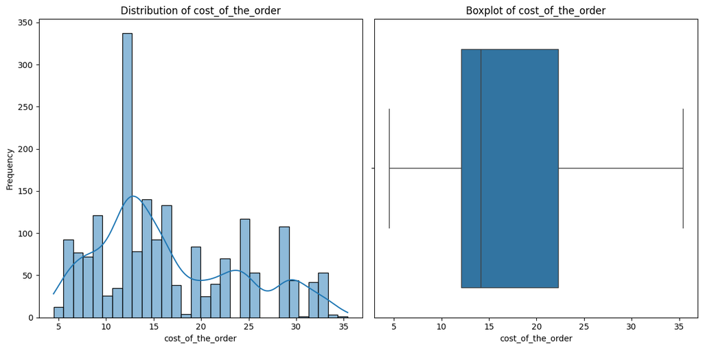

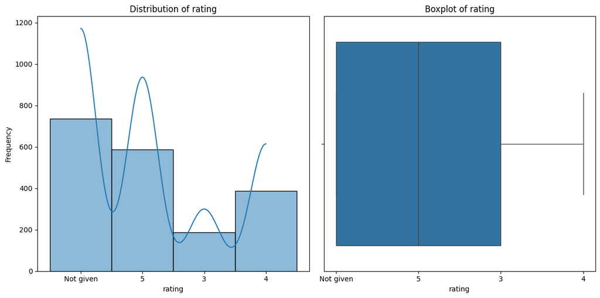

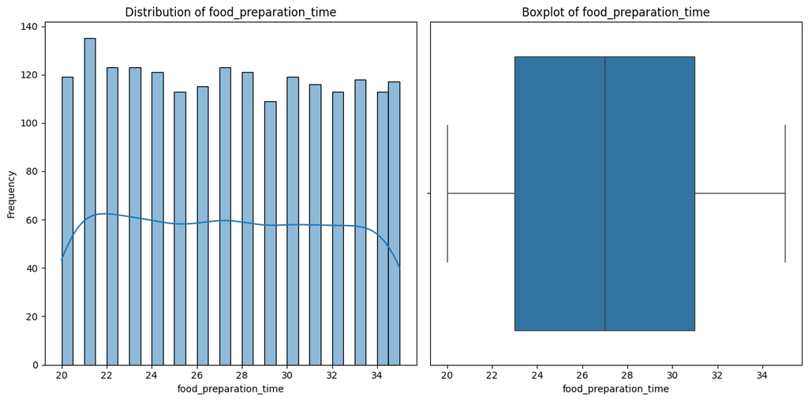

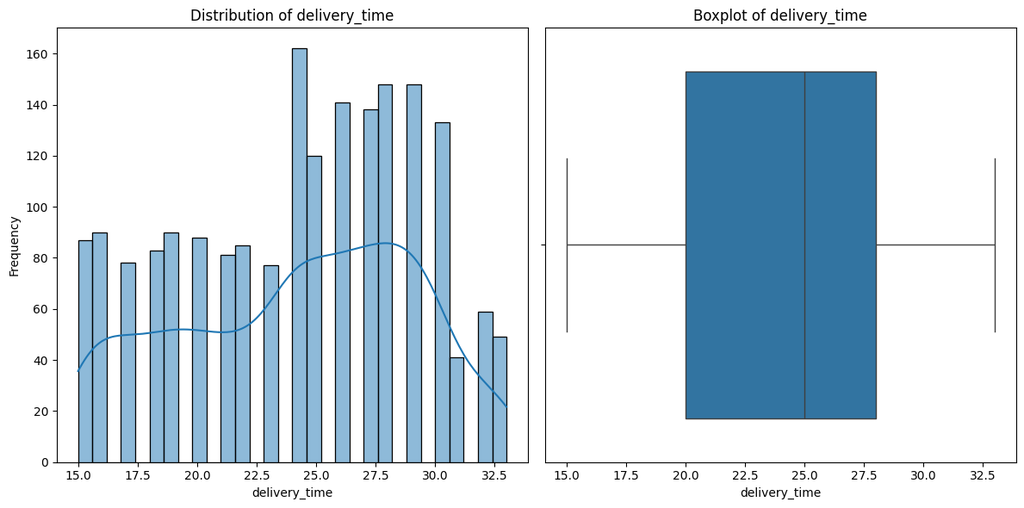

[figure not shown]

[figure not shown]

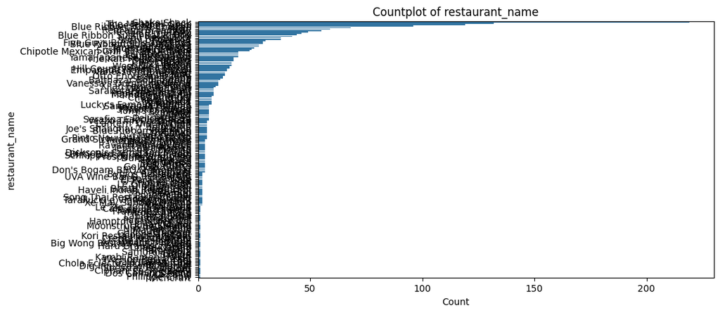

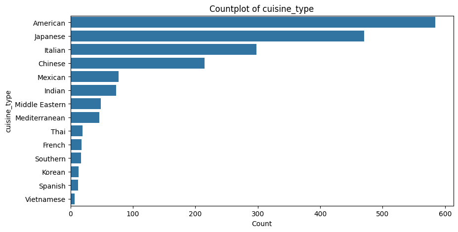

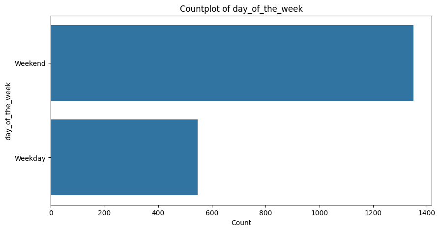

```python
numerical_Variables = ['cost_of_the_order', 'rating', 'food_preparation_time', 'delivery_time']
categorical_Variables = ['order_id', 'customer_id', 'restaurant_name', 'cuisine_type', 'day_of_the_week']


for i in numerical_Variables:
    plt.figure(figsize=(12, 6))

    # Histogram
    plt.subplot(1, 2, 1)
    sns.histplot(df[i], bins=30, kde=True)
    plt.title(f'Distribution of {i}')
    plt.xlabel(i)
    plt.ylabel('Frequency')

    # Boxplot
    plt.subplot(1, 2, 2)
    sns.boxplot(x=df[i])
    plt.title(f'Boxplot of {i}')
    plt.xlabel(i)

    plt.tight_layout()
    plt.show()

for j in categorical_Variables:
    plt.figure(figsize=(10, 5))
    sns.countplot(y=df[j], order=df[j].value_counts().index)
    plt.title(f'Countplot of {j}')
    plt.xlabel('Count')
    plt.ylabel(j)
    plt.show()
```

### **Question 7**: Which are the top 5 restaurants in terms of the number of orders received?

```python
restaurant_order_count = df['restaurant_name'].value_counts().head(5)
print("Top 5 restaurants by the number of orders received:")
print(restaurant_order_count)
```

```
Top 5 restaurants by the number of orders received:
restaurant_name
Shake Shack                  219
The Meatball Shop            132
Blue Ribbon Sushi            119
Blue Ribbon Fried Chicken     96
Parm                          68
Name: count, dtype: int64
```

#### Observations:

### **Question 8**: Which is the most popular cuisine on weekends?

```python
weekend_orders = df[df['day_of_the_week'].isin(['Weekend'])]
cuisine_popularity = weekend_orders['cuisine_type'].value_counts()# counts every category
most_popular_cuisine = cuisine_popularity.idxmax() # stores the largest value
print("The most popular cuisine on weekends is:", most_popular_cuisine)
```

```
The most popular cuisine on weekends is: American
```

#### Observations:

### **Question 9**: What percentage of the orders cost more than 20 dollars?

```python
total_orders = df.shape[0]
orders_above_20 = df[df['cost_of_the_order'] > 20].shape[0]
percentage_above_20 = (orders_above_20 / total_orders) * 100
print(f'Percentage of orders that cost more than 20 dollars: {percentage_above_20:.2f}%')
```

```
Percentage of orders that cost more than 20 dollars: 29.24%
```

#### Observations:

### **Question 10**: What is the mean order delivery time?

```python
MeanDelTime= df['delivery_time'].mean()
print(MeanDelTime)
```

```
24.161749209694417
```

#### Observations:

### **Question 11:** The company has decided to give 20% discount vouchers to the top 3 most frequent customers. Find the IDs of these customers and the number of orders they placed

```python
CustCount= df['customer_id'].value_counts().head(3)
print("Top 3 customers are")
print(CustCount)
```

```
Top 3 customers are
customer_id
52832    13
47440    10
83287     9
Name: count, dtype: int64
```

#### Observations:

### Multivariate Analysis

```python
df.head()
```

|  | order_id | customer_id | restaurant_name | cuisine_type | cost_of_the_order | day_of_the_week | rating | food_preparation_time | delivery_time |
| --- | --- | --- | --- | --- | --- | --- | --- | --- | --- |
| 0 | 1477147 | 337525 | Hangawi | Korean | 30.75 | Weekend | Not given | 25 | 20 |
| 1 | 1477685 | 358141 | Blue Ribbon Sushi Izakaya | Japanese | 12.08 | Weekend | Not given | 25 | 23 |
| 2 | 1477070 | 66393 | Cafe Habana | Mexican | 12.23 | Weekday | 5 | 23 | 28 |
| 3 | 1477334 | 106968 | Blue Ribbon Fried Chicken | American | 29.20 | Weekend | 3 | 25 | 15 |
| 4 | 1478249 | 76942 | Dirty Bird to Go | American | 11.59 | Weekday | 4 | 25 | 24 |

### **Question 12**: Perform a multivariate analysis to explore relationships between the important variables in the dataset. (It is a good idea to explore relations between numerical variables as well as relations between numerical and categorical variables)

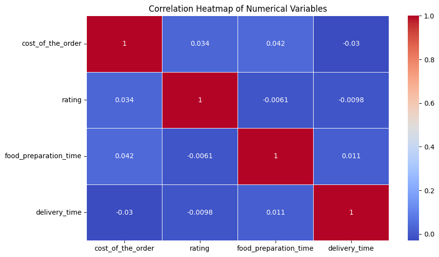

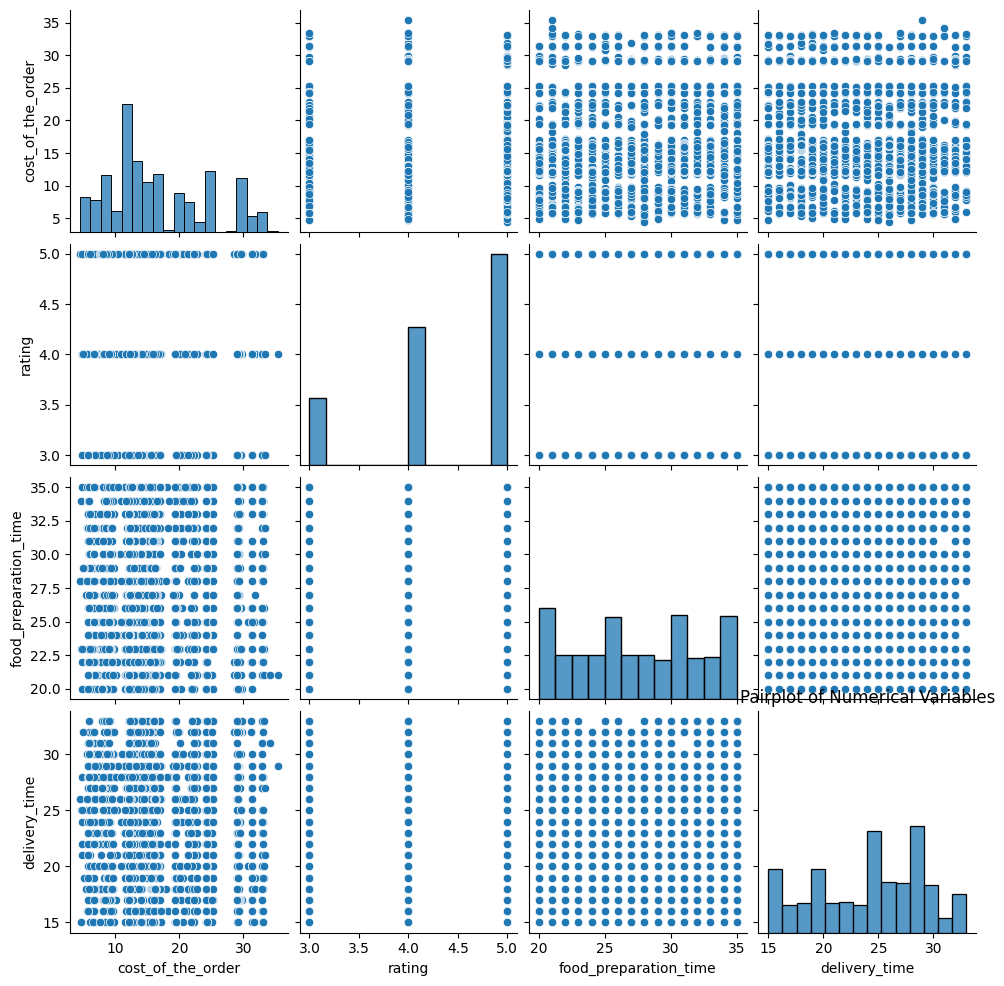

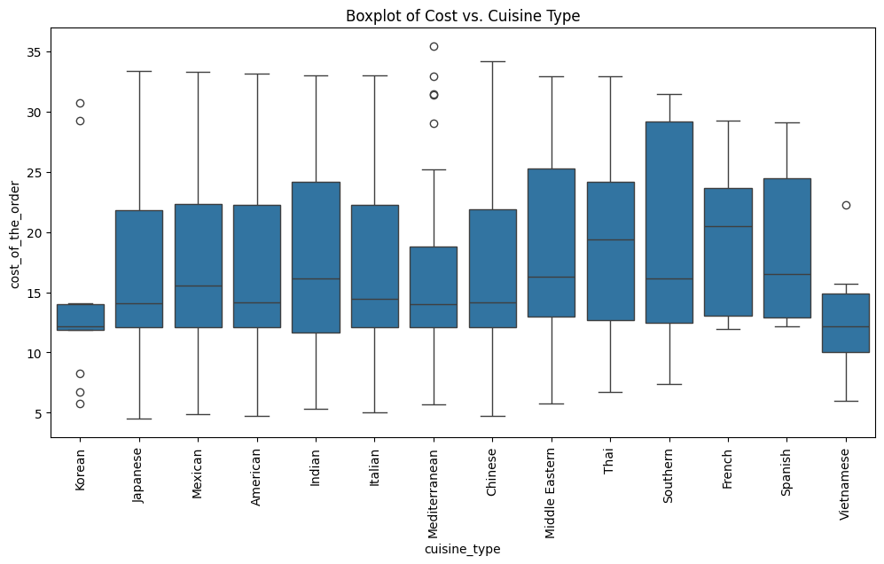

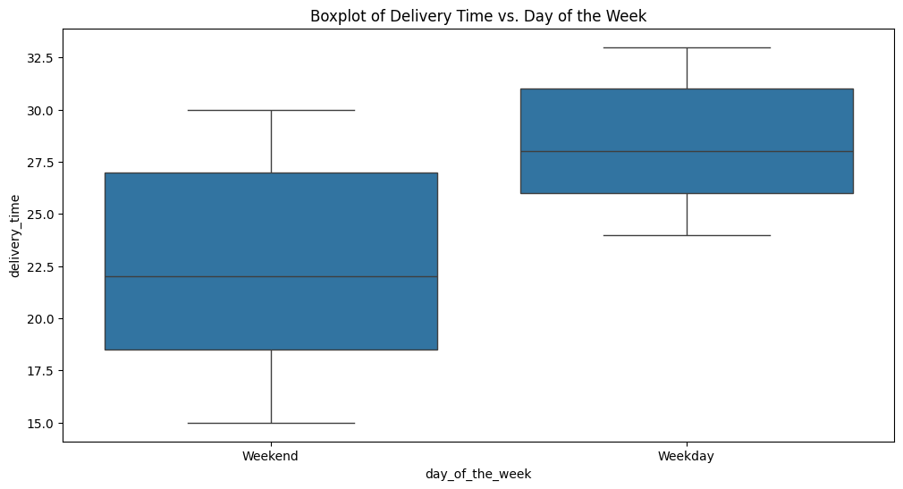

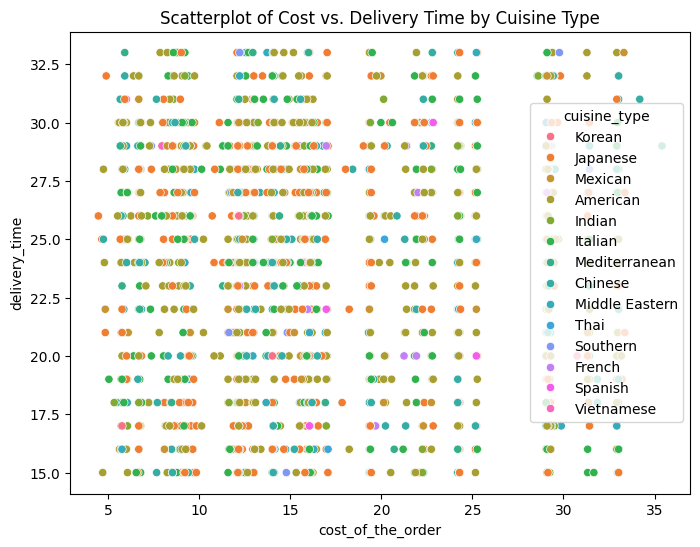

```python
# 1. Correlation Heatmap for numerical variables
plt.figure(figsize=(10, 6))
numerical_cols = ['cost_of_the_order', 'rating', 'food_preparation_time', 'delivery_time']
# Convert relevant columns to numeric, handling errors
for col in numerical_cols:
    df[col] = pd.to_numeric(df[col], errors='coerce')  # 'coerce' converts non-numeric to NaN
# Calculate correlation matrix only on numeric values
correlation_matrix = df[numerical_cols].corr(numeric_only=True)  # Added numeric_only=True
sns.heatmap(correlation_matrix, annot=True, cmap='coolwarm', linewidths=0.5)
plt.title('Correlation Heatmap of Numerical Variables')
plt.show()


# 2. Scatter plot for relationships between numerical variables
plt.figure(figsize=(12, 8))
sns.pairplot(df[numerical_cols])
plt.title('Pairplot of Numerical Variables')
plt.show()

# 3. Box plot for numerical variables vs. categorical variables (e.g., 'cuisine_type')
plt.figure(figsize=(12, 6))
sns.boxplot(x='cuisine_type', y='cost_of_the_order', data=df)
plt.xticks(rotation=90)
plt.title('Boxplot of Cost vs. Cuisine Type')
plt.show()

# 4. Box plot for 'day_of_the_week' vs 'delivery_time'
plt.figure(figsize=(12, 6))
sns.boxplot(x='day_of_the_week', y='delivery_time', data=df)
plt.title('Boxplot of Delivery Time vs. Day of the Week')
plt.show()

# 5. Scatter plot between 'cost' and 'delivery_time'
plt.figure(figsize=(8, 6))
sns.scatterplot(x='cost_of_the_order', y='delivery_time', hue='cuisine_type', data=df)
plt.title('Scatterplot of Cost vs. Delivery Time by Cuisine Type')
plt.show()
```

### **Question 13:** The company wants to provide a promotional offer in the advertisement of the restaurants. The condition to get the offer is that the restaurants must have a rating count of more than 50 and the average rating should be greater than 4. Find the restaurants fulfilling the criteria to get the promotional offer

```python
restaurant_ratings = df.groupby('restaurant_name').agg(
    rating_count=('rating', 'count'),
    avg_rating=('rating', 'mean')
).reset_index()
promotional_restaurants = restaurant_ratings[
    (restaurant_ratings['rating_count'] > 50) & (restaurant_ratings['avg_rating'] > 4)
]
print("Restaurants eligible for the promotional offer:")
print(promotional_restaurants)
```

```
Restaurants eligible for the promotional offer:
               restaurant_name  rating_count  avg_rating
20   Blue Ribbon Fried Chicken            64    4.328125
21           Blue Ribbon Sushi            73    4.219178
136                Shake Shack           133    4.278195
153          The Meatball Shop            84    4.511905
```

#### Observations:

### **Question 14:** The company charges the restaurant 25% on the orders having cost greater than 20 dollars and 15% on the orders having cost greater than 5 dollars. Find the net revenue generated by the company across all orders

```python
df['revenue'] = 0
df.loc[df['cost_of_the_order'] > 20, 'revenue'] = df['cost_of_the_order'] * 0.25
df.loc[(df['cost_of_the_order'] > 5) & (df['cost_of_the_order'] <= 20), 'revenue'] = df['cost_of_the_order'] * 0.15
total_revenue = df['revenue'].sum()
print(f'The net revenue generated by the company across all orders is ${total_revenue:.2f}')
```

```
The net revenue generated by the company across all orders is $6166.30
```

[output not shown]

#### Observations:

### **Question 15:** The company wants to analyze the total time required to deliver the food. What percentage of orders take more than 60 minutes to get delivered from the time the order is placed? (The food has to be prepared and then delivered)

```python
df['total_time'] = df['food_preparation_time'] + df['delivery_time']
percentage_long_delivery = (df['total_time'] > 60).mean() * 100
print(f'Percentage of orders that take more than 60 minutes to get delivered: {percentage_long_delivery:.2f}%')
```

```
Percentage of orders that take more than 60 minutes to get delivered: 10.54%
```

#### Observations:

### **Question 16:** The company wants to analyze the delivery time of the orders on weekdays and weekends. How does the mean delivery time vary during weekdays and weekends?

```python
mean_delivery_time = df.groupby('day_of_the_week')['delivery_time'].mean().reset_index()
print("Mean delivery time on weekdays and weekends:")
print(mean_delivery_time)
```

```
Mean delivery time on weekdays and weekends:
  day_of_the_week  delivery_time
0         Weekday      28.340037
1         Weekend      22.470022
```

#### Observations:

### Conclusion and Recommendations

### **Question 17:** What are your conclusions from the analysis? What recommendations would you like to share to help improve the business? (You can use cuisine type and feedback ratings to drive your business recommendations)

### Conclusions:

Revenue: A significant portion of the revenue comes from orders costing more than 20 dollars. This highlights the importance of high-value orders for the business.

Customer Loyalty: Identifying and rewarding frequent customers with discounts could improve customer retention.

Restaurant Performance: Some restaurants have consistently high ratings and order volumes, indicating areas for promotional offers or collaborations to enhance their visibility and attract more customers.

Operational Efficiency: Orders that take longer than 60 minutes for delivery require attention. Improving food preparation or delivery processes for these cases could improve customer satisfaction.

Customer Feedback: A substantial number of orders are not rated. Encouraging customers to provide feedback could offer valuable insights for service improvement.

### Recommendation : Implement a tiered reward system for customers based on order frequency and spending, offering benefits like free delivery, exclusive discounts, and early access to new restaurants or promotions